# EDA TITANIC

Hola a todos, en este notebook vamos a realizar un análisis exploratorio de datos (EDA) del famoso conjunto de datos del Titanic. Este conjunto de datos contiene información sobre los pasajeros del Titanic, incluyendo si sobrevivieron o no al desastre. El objetivo de este análisis es entender mejor los datos, identificar patrones y relaciones entre las variables, y preparar los datos para futuros modelos predictivos.

En este análisis, utilizaremos las siguientes bibliotecas de Python:

- Pandas: para la manipulación y análisis de datos.
- NumPy: para operaciones numéricas.
- Matplotlib y Seaborn: para la visualización de datos.

Lo mas importante de este Notebook es que vamos a hacer un EDA COMPLETO y PROFUNDO, no solo un EDA superficial como muchos otros notebooks que se encuentran en internet.

```python
import pandas as pd
import numpy as np
import matplotlib.pyplot as plt
import warnings
warnings.filterwarnings("ignore")



# Cargar los datos
df = pd.read_csv("../data/train.csv")

# Creamos 2 copias del dataframe original
df_raw = df.copy()
df_clean = df.copy()
```

## Fase 1 : Exploración

En esta fase vamos a explorar el dataset para entender mejor su estructura y contenido. Vamos a analizar las columnas, los tipos de datos, los valores nulos y las estadísticas descriptivas.

#### 1.1 Vamos a ver informacion basica del dataset

Vamos a ver las primeras filas del dataset

```python
df_clean.head()  # Mostrar las primeras filas del dataframe
```

|  | PassengerId | Survived | Pclass | Name | Sex | Age | SibSp | Parch | Ticket | Fare | Cabin | Embarked |
| --- | --- | --- | --- | --- | --- | --- | --- | --- | --- | --- | --- | --- |
| 0 | 1 | 0 | 3 | Braund, Mr. Owen Harris | male | 22.0 | 1 | 0 | A/5 21171 | 7.2500 | NaN | S |
| 1 | 2 | 1 | 1 | Cumings, Mrs. John Bradley (Florence Briggs Th... | female | 38.0 | 1 | 0 | PC 17599 | 71.2833 | C85 | C |
| 2 | 3 | 1 | 3 | Heikkinen, Miss. Laina | female | 26.0 | 0 | 0 | STON/O2. 3101282 | 7.9250 | NaN | S |
| 3 | 4 | 1 | 1 | Futrelle, Mrs. Jacques Heath (Lily May Peel) | female | 35.0 | 1 | 0 | 113803 | 53.1000 | C123 | S |
| 4 | 5 | 0 | 3 | Allen, Mr. William Henry | male | 35.0 | 0 | 0 | 373450 | 8.0500 | NaN | S |

Vamos a ver las ultimas filas del dataset

```python
df_clean.tail()  # Mostrar las primeras filas del dataframe
```

|  | PassengerId | Survived | Pclass | Name | Sex | Age | SibSp | Parch | Ticket | Fare | Cabin | Embarked |
| --- | --- | --- | --- | --- | --- | --- | --- | --- | --- | --- | --- | --- |
| 886 | 887 | 0 | 2 | Montvila, Rev. Juozas | male | 27.0 | 0 | 0 | 211536 | 13.00 | NaN | S |
| 887 | 888 | 1 | 1 | Graham, Miss. Margaret Edith | female | 19.0 | 0 | 0 | 112053 | 30.00 | B42 | S |
| 888 | 889 | 0 | 3 | Johnston, Miss. Catherine Helen "Carrie" | female | NaN | 1 | 2 | W./C. 6607 | 23.45 | NaN | S |
| 889 | 890 | 1 | 1 | Behr, Mr. Karl Howell | male | 26.0 | 0 | 0 | 111369 | 30.00 | C148 | C |
| 890 | 891 | 0 | 3 | Dooley, Mr. Patrick | male | 32.0 | 0 | 0 | 370376 | 7.75 | NaN | Q |

Vamos a ver tamaño del dataset , tipos de datos y resumen general del dataset

```python
df_clean.info()
```

```
<class 'pandas.core.frame.DataFrame'>
RangeIndex: 891 entries, 0 to 890
Data columns (total 12 columns):
 #   Column       Non-Null Count  Dtype
---  ------       --------------  -----
 0   PassengerId  891 non-null    int64
 1   Survived     891 non-null    int64
 2   Pclass       891 non-null    int64
 3   Name         891 non-null    object
 4   Sex          891 non-null    object
 5   Age          714 non-null    float64
 6   SibSp        891 non-null    int64
 7   Parch        891 non-null    int64
 8   Ticket       891 non-null    object
 9   Fare         891 non-null    float64
 10  Cabin        204 non-null    object
 11  Embarked     889 non-null    object
dtypes: float64(2), int64(5), object(5)
memory usage: 83.7+ KB
```

```python
df_clean.shape
```

```
(891, 12)
```

```python
df_clean.isna().sum()
```

```
PassengerId      0
Survived         0
Pclass           0
Name             0
Sex              0
Age            177
SibSp            0
Parch            0
Ticket           0
Fare             0
Cabin          687
Embarked         2
dtype: int64
```

Se observa que los tipos de datos de datos son: int64 , float64 y object (cadenas de texto).

En total son 891 de entradas y 12 columnas. En otras palabras, tenemos 891 pasajeros y 12 características (columnas) para cada pasajero.

La memoria utilizada por el DataFrame es de 83.7 KB. Esto es importante tenerlo en cuenta si estamos trabajando con conjuntos de datos muy grandes, ya que puede afectar el rendimiento de nuestro análisis.

Vemos que hay varias columnas con valores nulos (NaN):

- La columna "Age" tiene 177 valores nulos.
- La columna "Cabin" tiene 687 valores nulos.
- La columna "Embarked" tiene 2 valores nulos.

Esto indica que hay datos faltantes en estas columnas, lo cual es un aspecto importante a considerar durante la limpieza de datos.

Las columnas "PassengerId", "Survived", "Pclass", "SibSp", "Parch" y "Fare" no tienen valores nulos, lo que significa que están completas para todos los pasajeros.

### 1. Carga de datos y hacemos copias de seguridad

Comenzamos cargando los datos del Titanic desde un archivo CSV utilizando Pandas.

### 1.2 Revisamos si hay duplicados en el dataset

Vamos a revisar si hay filas duplicadas en el dataset

```python
df_clean.columns
df_clean.duplicated().sum()  # Revisar si hay filas duplicadas en el dataset
```

```
np.int64(0)
```

Como podemos ver, no hay filas duplicadas en el dataset, ya que el resultado es 0. Esto significa que cada fila en el DataFrame es única y no hay registros repetidos.

### 1.3 Vamos a ver una vista rapida de las estadisticas descriptivas del dataset

Vamos a ver las estadisticas descriptivas del dataset

```python
df_clean.describe( include = "all" )  # Estadísticas descriptivas del DataFrame
```

|  | PassengerId | Survived | Pclass | Name | Sex | Age | SibSp | Parch | Ticket | Fare | Cabin | Embarked |
| --- | --- | --- | --- | --- | --- | --- | --- | --- | --- | --- | --- | --- |
| count | 891.000000 | 891.000000 | 891.000000 | 891 | 891 | 714.000000 | 891.000000 | 891.000000 | 891 | 891.000000 | 204 | 889 |
| unique | NaN | NaN | NaN | 891 | 2 | NaN | NaN | NaN | 681 | NaN | 147 | 3 |
| top | NaN | NaN | NaN | Braund, Mr. Owen Harris | male | NaN | NaN | NaN | 347082 | NaN | B96 B98 | S |
| freq | NaN | NaN | NaN | 1 | 577 | NaN | NaN | NaN | 7 | NaN | 4 | 644 |
| mean | 446.000000 | 0.383838 | 2.308642 | NaN | NaN | 29.699118 | 0.523008 | 0.381594 | NaN | 32.204208 | NaN | NaN |
| std | 257.353842 | 0.486592 | 0.836071 | NaN | NaN | 14.526497 | 1.102743 | 0.806057 | NaN | 49.693429 | NaN | NaN |
| min | 1.000000 | 0.000000 | 1.000000 | NaN | NaN | 0.420000 | 0.000000 | 0.000000 | NaN | 0.000000 | NaN | NaN |
| 25% | 223.500000 | 0.000000 | 2.000000 | NaN | NaN | 20.125000 | 0.000000 | 0.000000 | NaN | 7.910400 | NaN | NaN |
| 50% | 446.000000 | 0.000000 | 3.000000 | NaN | NaN | 28.000000 | 0.000000 | 0.000000 | NaN | 14.454200 | NaN | NaN |
| 75% | 668.500000 | 1.000000 | 3.000000 | NaN | NaN | 38.000000 | 1.000000 | 0.000000 | NaN | 31.000000 | NaN | NaN |
| max | 891.000000 | 1.000000 | 3.000000 | NaN | NaN | 80.000000 | 8.000000 | 6.000000 | NaN | 512.329200 | NaN | NaN |

#### Analisis de las estadísticas descriptivas:

Podemos observar varias cosas interesantes en las estadísticas descriptivas del DataFrame:

- La columna "PassengerId" es simplemente un identificador único para cada pasajero, por lo que no tiene mucha relevancia estadística.
- La columna "Survived" es la variable objetivo que indica si el pasajero sobrevivió (1) o no (0). La media de esta columna es aproximadamente 0.38, lo que sugiere que alrededor del 38% de los pasajeros sobrevivieron.
- La columna "Pclass" representa la clase del pasajero (1, 2 o 3). La media es aproximadamente 2.31, lo que indica que la mayoría de los pasajeros estaban en la tercera clase.
- La columna "Sex" es una variable categórica que indica el género del pasajero. No tiene estadísticas numéricas, pero podemos ver que hay 577 pasajeros masculinos y 314 femeninos.
- La columna "Age" tiene una media de aproximadamente 29.7 años, con una desviación estándar de 14.5 años. El rango de edad va desde 0.42 hasta 80 años, lo que indica una amplia variedad de edades entre los pasajeros.
- La columna "SibSp" indica el número de hermanos/esposas a bordo. La media es aproximadamente 0.52, lo que sugiere que la mayoría de los pasajeros no tenían hermanos o esposas a bordo.
- La columna "Parch" indica el número de padres/hijos a bordo. La media es aproximadamente 0.38, lo que sugiere que la mayoría de los pasajeros no tenían padres o hijos a bordo.
- La columna "Fare" representa la tarifa pagada por el pasajero. La media es aproximadamente 32.2, con una desviación estándar de 49.7. El rango de tarifas va desde 0 hasta 512.33, lo que indica una gran variabilidad en las tarifas pagadas por los pasajeros. La mediana es 14.45, lo que sugiere que la mayoría de las tarifas pagadas fueron relativamente bajas, pero hay algunos pasajeros que pagaron tarifas muy altas, lo que eleva la media.
- La columna "Embarked" es una variable categórica que indica el puerto de embarque del pasajero (C = Cherbourg, Q = Queenstown, S = Southampton). No tiene estadísticas numéricas, pero podemos ver que la mayoría de los pasajeros embarcaron en Southampton (644), seguido de Cherbourg (168) y Queenstown (77).

### Conclusion de la Fase 1:

En esta fase hemos realizado una exploración inicial del dataset del Titanic. Hemos cargado los datos, inspeccionado las primeras filas, revisado el tamaño y la estructura del DataFrame, y analizado las estadísticas descriptivas. Hemos identificado algunas columnas con valores nulos que requerirán atención en la fase de limpieza de datos. En la siguiente fase, nos centraremos en la limpieza de datos para preparar el conjunto de datos para un análisis más profundo.

## Fase 2 : Limpieza de datos

En esta fase vamos a limpiar el dataset para preparar los datos para un análisis más profundo.

Pero antes de continuar , tengo que decidir que camino tomar y especializarlo en un area especifica del EDA , ya que el EDA es muy amplio y no se puede cubrir todo en un solo notebook. Ademas es mas profundo especializarse en un area especifica del EDA.

El area que he decidido especializar este EDA es en la Supervivencia de los pasajeros del Titanic, ya que es el objetivo principal del dataset y es un tema de gran interés historico y social. Ademas es muy bueno para proyectos de ML y Data Science.

### 2.1 Vamos a eliminar duplicados

Esto es bueno para asegurarnos de que no hay registros repetidos en el dataset, lo cual podría sesgar los resultados del análisis.

En nuestro caso ya indifique que no hay filas duplicadas en el dataset, ya que el resultado es 0. Por lo tanto, no es necesario eliminar duplicados en este caso.

```python
df_clean.duplicated().sum()  # Revisar si hay filas duplicadas en el dataset
```

```
np.int64(0)
```

Si fuera el caso de que hubiera filas duplicadas, podríamos eliminarlas utilizando el siguiente código:

```
df_clean.drop_duplicates(inplace=True)
```

### 2.2 Vamos a corregir los nombres de las columnas

Es importante tener nombres de columnas claros y consistentes para facilitar el análisis y la interpretación de los datos. Vamos a cambiar los nombres de las columnas para que sean mas claros y consistentes.

```python
df_clean.columns
```

```
Index(['PassengerId', 'Survived', 'Pclass', 'Name', 'Sex', 'Age', 'SibSp',
       'Parch', 'Ticket', 'Fare', 'Cabin', 'Embarked'],
      dtype='object')
```

Aqui se puede ver que los nombres estan bien , no es necesario cambiarlos para un Junior. Pero un profesional podria cambiarlos para que sean mas claros y consistentes. El unico cambio seria ponerlo en minuscula.

```python
df_clean.columns = df_clean.columns.str.lower().str.strip()
```

Si ven no habia necesidad de usar strip() ya que no hay espacios en los nombres de las columnas. Pero es una buena practica usarlo por si acaso.

### 2.3 Vamos a manejar los valores nulos

Los valores nulos pueden afectar el análisis y los resultados de los modelos predictivos. Por lo tanto, es importante manejarlos adecuadamente.

Cuando tenemos nulos , no hay una unica forma de manejarlos, depende del contexto y del objetivo del análisis.

Depende de 3 cosas:

1. Cantidad de nulos
2. Importancia de la columna
3. Si los nulos tienen un significado especial o no.

Veamos las columnas con nulos de nuevo:

```python
df_clean.isna().sum()  # Revisar si hay valores nulos en el dataset
```

```
passengerid      0
survived         0
pclass           0
name             0
sex              0
age            177
sibsp            0
parch            0
ticket           0
fare             0
cabin          687
embarked         2
dtype: int64
```

- La columna "Age" tiene 177 valores nulos.
- La columna "Cabin" tiene 687 valores nulos.
- La columna "Embarked" tiene 2 valores nulos.

Que significa esto?

Es una falta real? Dato no registrado? Condicion que dice algo?

```python
### Calculamos la cantidad y porcentaje de valores nulos en cada columna

faltantes = df_clean.isna().sum()

porcentaje = (faltantes / len(df_clean)) * 100

faltantes_df = pd.DataFrame({'Cantidad de valores nulos': faltantes, 'Porcentaje': porcentaje }).sort_values(by='Cantidad de valores nulos', ascending=False)

print(faltantes_df)
```

```
             Cantidad de valores nulos  Porcentaje
cabin                              687   77.104377
age                                177   19.865320
embarked                             2    0.224467
passengerid                          0    0.000000
survived                             0    0.000000
pclass                               0    0.000000
name                                 0    0.000000
sex                                  0    0.000000
sibsp                                0    0.000000
parch                                0    0.000000
ticket                               0    0.000000
fare                                 0    0.000000
```

#### Decisicion sobre cabin

Situacion con columna "Cabin": La columna "Cabin" tiene 687 valores nulos, lo que representa aproximadamente el 77% del total de entradas. Esto es una cantidad significativa de datos faltantes.

La falte la cabina podria indicar que el pasajero no tenia una cabina asignada, lo que podria estar relacionado con su clase o tarifa pagada. Por eso no la voy a eliminar la columna "Cabin" ya que podria tener un significado especial.

No la borramos pero la transformamos en una columna binaria que indique si el pasajero tenia cabina o no. Esto podria ser util para el analisis de supervivencia.

```python
df_clean['Has_Cabin'] = df_clean['cabin'].notna().astype(int)
df_clean.drop(columns='cabin', inplace=True)
```

#### Decision sobre Age

La columna "Age" tiene 177 valores nulos, lo que representa aproximadamente el 20% del total de entradas. Esto es una cantidad significativa de datos faltantes.

Un Junior podria eliminar las filas con valores nulos en la columna "Age", pero esto podria resultar en la perdida de informacion valiosa, ya que se perderian 177 filas del dataset. Un semi podria usar la mediana global para rellenar los nulos, pero esto podria no ser representativo para todos los pasajeros, ya que la edad puede variar significativamente entre diferentes grupos de pasajeros (por ejemplo, niños, adultos, ancianos).

Un senior imputaria los valores nulos de "Age" utilizando la clase y el sexo del pasajero. Por ejemplo, podria calcular la mediana de la edad para cada combinacion de clase y sexo, y luego usar esos valores para rellenar los nulos. Esto podria proporcionar una estimacion mas precisa de la edad para cada pasajero.

##### Decicion sobre la imputacion

Vamos a imputar los valores nulos de "Age" utilizando la clase y el sexo del pasajero.

La cosa es que debemos saber si usamos la media o la mediana. Si los datos estan sesgados, es mejor usar la mediana, ya que no se ve afectada por los valores extremos.

Pero si los datos estan normalmente distribuidos, es mejor usar la media, ya que utiliza toda la informacion disponible.

Tenemos 2 maneras verlo con seaborn y con histplot o skew()

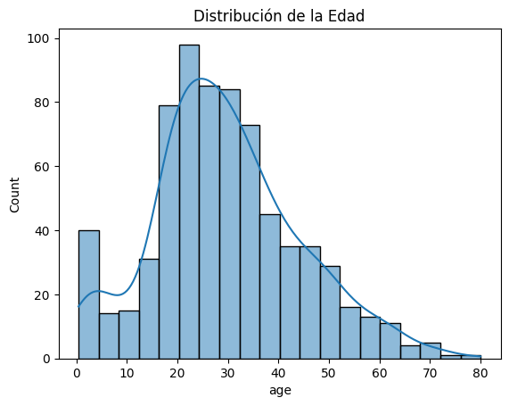

```python
import seaborn as sns
import matplotlib.pyplot as plt

sns.histplot(df_clean['age'] , kde=True)
plt.title('Distribución de la Edad')
plt.show()
```

Pero igual si queremos verificar podemos usar skew()

```python
df_clean["age"].skew()
```

```
np.float64(0.38910778230082704)
```

Si fuera 0 seria una distribucion normal y usariamos la media.

Si esta entre -0.5 y 0.5 es una distribucion aproximadamente normal y usariamos la media.

si es mayoir es sesgada a la derecha y usariamos la mediana.

si es menor a -0.5 es sesgada a la izquierda y usariamos la mediana.

```python
df_clean["age"] = df_clean.groupby(["pclass", "sex"])["age"].transform(lambda x: x.fillna(x.median()))
```

Lo que hicimos fue una imputacion contextualizada, es decir, usamos la informacion disponible (clase y sexo) para hacer una estimacion mas precisa de la edad de cada pasajero.

NO GENERICAL, ya que cada dataset es diferente y requiere un analisis y una estrategia de limpieza de datos personalizada.

#### Decision sobre Embarked

La columna "Embarked" tiene 2 valores nulos, lo que representa aproximadamente el 0.22% del total de entradas. Esto es una cantidad muy pequeña de datos faltantes.

Vale la pena hacer complejo solo para 2 nulos?

Un junior piensa en hacer algo con ellos Un Senior piensa si vale la pena invertir tiempo en hacer algo complejo para solo 2 nulos. El 0.22% es muy pequeño, por lo que no vale la pena hacer algo complejo. Este dato no va a afectar de forma significativa el analisis.

```python
df_clean["embarked"].fillna(df_clean["embarked"].mode()[0], inplace=True)
```

#### VERIFICAMOS QUE NO HAY MAS NULOS

Ahora vamos a verificar que no hay mas nulos en el dataset despues de la limpieza de datos.

```python
df_clean.isna().sum()  # Revisar si hay valores nulos en el dataset
```

```
passengerid    0
survived       0
pclass         0
name           0
sex            0
age            0
sibsp          0
parch          0
ticket         0
fare           0
embarked       0
Has_Cabin      0
dtype: int64
```

Como podemos ver, no hay mas valores nulos en el dataset despues de la limpieza de datos. Esto significa que hemos manejado adecuadamente los valores nulos y el dataset esta listo para un analisis mas profundo.

#### Correccion de tipos de datos

Para finalizar la limpieza de datos, vamos a corregir los tipos de datos de las columnas si es necesario. Esto es importante para asegurarnos de que las operaciones y analisis que realizamos en las columnas sean correctas y eficientes.

```python
df_clean.info()
```

```
<class 'pandas.core.frame.DataFrame'>
RangeIndex: 891 entries, 0 to 890
Data columns (total 12 columns):
 #   Column       Non-Null Count  Dtype
---  ------       --------------  -----
 0   passengerid  891 non-null    int64
 1   survived     891 non-null    int64
 2   pclass       891 non-null    int64
 3   name         891 non-null    object
 4   sex          891 non-null    object
 5   age          891 non-null    float64
 6   sibsp        891 non-null    int64
 7   parch        891 non-null    int64
 8   ticket       891 non-null    object
 9   fare         891 non-null    float64
 10  embarked     891 non-null    object
 11  Has_Cabin    891 non-null    int64
dtypes: float64(2), int64(6), object(4)
memory usage: 83.7+ KB
```

##### Analizar los tipos de datos

Vamos a revisar si nuestro dataset tiene los tipos de datos correctos para cada columna. Como podemos ver, los tipos de datos de las columnas son los siguientes:

```python
df_clean["survived"] = df_clean["survived"].astype("category")
df_clean["pclass"] = df_clean["pclass"].astype("category")
df_clean["sex"] = df_clean["sex"].astype("category")
df_clean["embarked"] = df_clean["embarked"].astype("category")
df_clean["Has_Cabin"] = df_clean["Has_Cabin"].astype("category")
```

```python
df_clean.info()
```

```
<class 'pandas.core.frame.DataFrame'>
RangeIndex: 891 entries, 0 to 890
Data columns (total 12 columns):
 #   Column       Non-Null Count  Dtype
---  ------       --------------  -----
 0   passengerid  891 non-null    int64
 1   survived     891 non-null    category
 2   pclass       891 non-null    category
 3   name         891 non-null    object
 4   sex          891 non-null    category
 5   age          891 non-null    float64
 6   sibsp        891 non-null    int64
 7   parch        891 non-null    int64
 8   ticket       891 non-null    object
 9   fare         891 non-null    float64
 10  embarked     891 non-null    category
 11  Has_Cabin    891 non-null    category
dtypes: category(5), float64(2), int64(3), object(2)
memory usage: 53.8+ KB
```

Listo , hemos corregido los tipos de datos de las columnas que lo necesitaban. Ahora el dataset esta listo para un analisis mas profundo.

## Fase 3 : Analisis univariado

En esta fase se va a analizar la distribución de cada variable individualmente. Esto nos ayudará a entender mejor los datos y a identificar patrones y relaciones entre las variables.

La pregunta que respondemos es : “¿Qué me dice esta columna por sí sola sobre el conjunto de datos?”

Primero metemos a las columnas en una lista para analizarlas una por una.

```python
numeric_cols = [ "age", "sibsp", "parch", "fare" ]
categorical_cols = [ "survived", "pclass", "sex", "embarked", "Has_Cabin" ]
```

### Analizar variables numericas

Las variables numericas en nuestro dataset son:

- PassengerId (no tiene sentido analizarlo ya que es un identificador unico)
- Age
- SibSp
- Parch
- Fare

```python
df_clean[numeric_cols].describe().T #La T es para transponer el dataframe , osea , para que las filas sean las columnas y viceversa.
```

|  | count | mean | std | min | 25% | 50% | 75% | max |
| --- | --- | --- | --- | --- | --- | --- | --- | --- |
| age | 891.0 | 29.112424 | 13.304424 | 0.42 | 21.5000 | 26.0000 | 36.0 | 80.0000 |
| sibsp | 891.0 | 0.523008 | 1.102743 | 0.00 | 0.0000 | 0.0000 | 1.0 | 8.0000 |
| parch | 891.0 | 0.381594 | 0.806057 | 0.00 | 0.0000 | 0.0000 | 0.0 | 6.0000 |
| fare | 891.0 | 32.204208 | 49.693429 | 0.00 | 7.9104 | 14.4542 | 31.0 | 512.3292 |

Un analisis rapido de las estadisticas descriptivas de las variables numericas nos muestra lo siguiente:

-AGE: La edad media de los pasajeros es de aproximadamente 29.1 años, con una desviación estándar de 13.30 años. La edad mínima es de 0.42 años y la máxima es de 80 años. Esto indica que había una amplia variedad de edades entre los pasajeros, desde bebés hasta ancianos.

Que la desviacion estandar sea alta indica que hay mucha variabilidad en las edades de los pasajeros.

-SIBSP: La mayoría de los pasajeros no tenían hermanos o esposas a bordo (mediana de SibSp es 0). La desviación estándar es 1.10, lo que indica que hay cierta variabilidad en el número de hermanos/esposas a bordo, pero la mayoría de los pasajeros tenían pocos o ningún familiar a bordo. El minimo es 0 y el maximo es 8.

-Parch: La mayoría de los pasajeros no tenían padres o hijos a bordo (mediana de Parch es 0). La desviación estándar es 0.80, lo que indica que hay cierta variabilidad en el número de padres/hijos a bordo, pero la mayoría de los pasajeros tenían pocos o ningún familiar a bordo. El minimo es 0 y el maximo es 6.

-Fare: La tarifa media pagada por los pasajeros es de aproximadamente 32.20, con una desviación estándar de 49.69. Eso significa que hay una gran variabilidad en las tarifas pagadas por los pasajeros. La tarifa mínima es 0 y la máxima es 512.33, lo que indica que algunos pasajeros pagaron tarifas muy altas, mientras que otros pagaron tarifas muy bajas o incluso no pagaron nada (probablemente niños o personal de servicio).

#### Tiempo para visualizar las variables numericas

Vamos a utilizar la biblioteca seaborn y matplotlib para crear histogramas y boxplots de las variables numericas. Esto nos ayudará a visualizar la distribución de cada variable y a identificar posibles outliers.

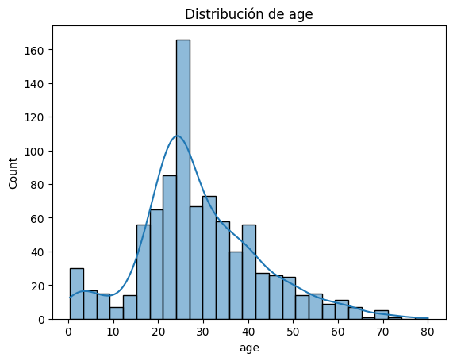

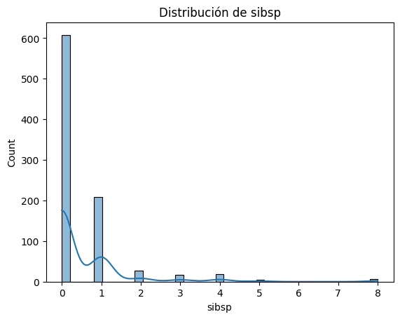

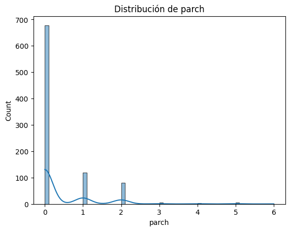

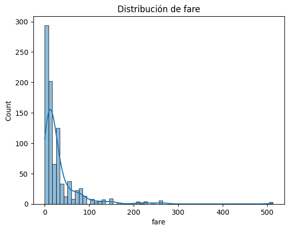

```python
for col in numeric_cols:
    sns.histplot(df_clean[col], kde=True)
    plt.title(f'Distribución de {col}')
    plt.show()
```

#### Analisis de sus histogramas

En Age :

- Parece una campana , con mas pasajeros jovenes que ancianos. (Hay mas de 20 a 40 años)
- Hay una pequeña cola a la derecha , lo que indica que hay algunos pasajeros ancianos.

Que significa esto?

- La distribucion esta casi normal
- La mayoria eran adultos jovenes
- Pocos ninos y ancianos

Una pregunta que podemos resolver es : ¿Habia mas jovenes que ancianos en el Titanic?

Si , la mayoria eran adultos jovenes. Entre 20 y 40 años.

En SibSp:

- Una gran barra en 0 (la mayoria no tenian hermanos o esposas a bordo) -Pocas personas con 1 o mas , hasta 8

Que significa esto?

- Distribucion sesgada a la derecha (Muy sesgada)
- La mayoria viajaba sola o con pocos familiares ( puede haber amantes o parejas jejeje)
- Pocos viajaban con muchos familiares (familias grandes)

Una pregunta que podemos resolver es : ¿La mayoria de los pasajeros viajaban solos o con pocos familiares?

Si , la mayoria viajaba sola o con pocos familiares.

En Parch:

- Una gran y inmensa barra en 0 (la mayoria no tenian padres o hijos a bordo)
- Pocas personas con 1 o mas , hasta 6

Que significa esto?

Una pregunta que podemos resolver es : ¿La mayoria de los pasajeros viajaban con sus padres o hijos? No , la mayoria no tenian padres o hijos a bordo.

En Fare:

- Una barra muy alta en 0 (muchos pasajeros pagaron tarifas bajas o no pagaron nada)
- Muchas barras bajas entre 0 y 100 (la mayoria pagaron tarifas bajas)

Esto que significa?

- Distribucion sesgada a la derecha (Muy sesgada)
- La mayoria pagaron tarifas bajas
- Pocos pagaron tarifas altas
- Alta dispersion , osea gran diferencia economica entre los pasajeros

Una pregunta que podemos resolver es : ¿La mayoria de los pasajeros pagaron tarifas bajas? Si , la mayoria pagaron tarifas bajas. Habia desigualdad economica entre los pasajeros.

La media y mediana son iguales cuando la distribucion es simetrica o normal. Osea , cuando no hay sesgo. Si el sesgo esta a la derecha la media es mayor que la mediana. Si el sesgo esta a la izquierda la media es menor que la mediana.

#### Analisis de los boxplots

Los boxplots nos ayudan a identificar posibles outliers en las variables numericas. Un outlier es un valor que se encuentra muy alejado del resto de los datos. Los outliers pueden afectar el analisis y los resultados de los modelos predictivos, por lo que es importante identificarlos y manejarlos adecuadamente.

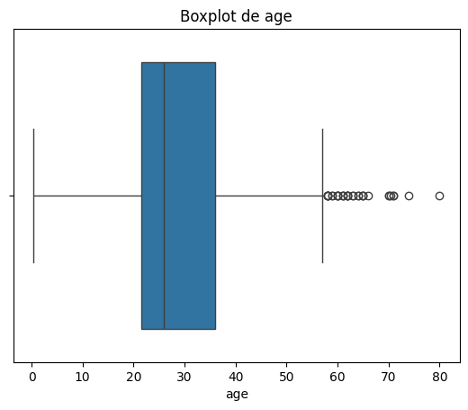

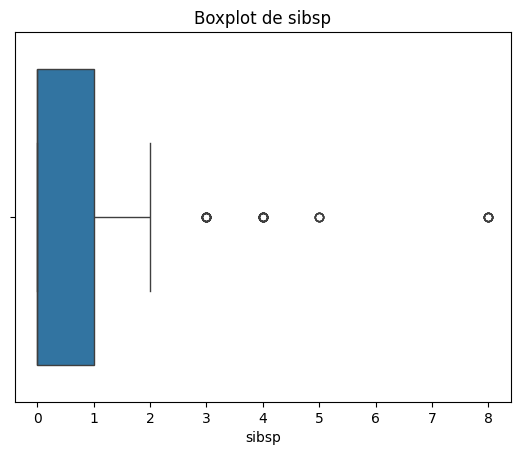

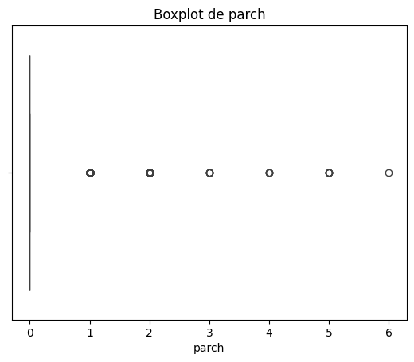

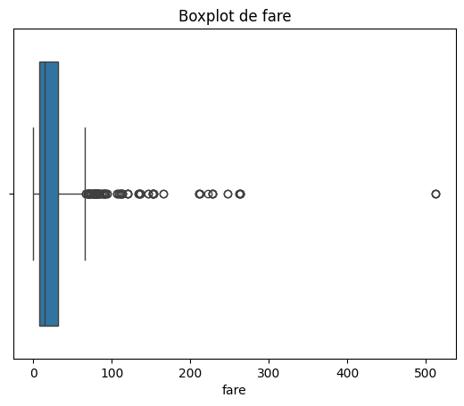

```python
for col in numeric_cols:
    sns.boxplot(x=df_clean[col])
    plt.title(f'Boxplot de {col}')
    plt.show()
```

Para age:

QUE VEO?

- La caja va entre 20 y 40 años (el 50% de los pasajeros tienen entre estas edades)
- La mediana esta cerca del centro de la caja (la distribucion es casi simetrica)
- La mediana esta cerca de los 30 , 26-27 pienso
- Hay bolsas de outliers a la derecha (ancianos)
- Las bolitas van desde los 60 hasta los 80 años (ancianos)

La edad tiene poco outliers, pero no son muchos. No es necesario hacer nada con ellos, ya que son pasajeros ancianos que realmente existieron. No los vamos a eliminar ni transformar, ya que son datos validos y no afectan de forma significativa el analisis.

Para SibSp:

QUE VEO?

- La caja va entre 0 y 1 (el 50% de los pasajeros tienen entre 0 y 1 hermanos)
- La mediana esta en 0 (la mayoria no tenian hermanos o esposas a bordo)
- Hay muchos outliers a la derecha (familias grandes)
- Las bolitas van desde 3 hasta 8 (familias muy grandes)
- No hay 6 ni 7 hermanos (Curioso)

Estos outliers no son errores, son pasajeros que realmente existieron y viajaban con muchas familias. No los vamos a eliminar ni transformar, ya que son datos validos y no afectan de forma significativa el analisis.

Tal vez las familias grandes tenian mas posibilidades de sobrevivir, ya que se ayudaban entre ellos. Pero eso lo veremos en el analisis bivariado.

Para Parch:

QUE VEO?

Los outliers no son errores, son pasajeros que realmente existieron y viajaban con muchas familias. No los vamos a eliminar ni transformar, ya que son datos validos y no afectan de forma significativa el analisis.

Para Fare:

QUE VEO?

-La caja va entre 7.91 y 31-50(el 50% de los pasajeros pagaron entre estas tarifas)

Los outliers no son errores, son pasajeros que realmente existieron y pagaron tarifas muy altas. No los vamos a eliminar ni transformar, ya que son datos validos y no afectan de forma significativa el analisis.

Hay una distribucion desigual de las tarifas pagadas por los pasajeros, lo que indica una gran diferencia economica entre ellos. Pero eso lo veremos en el analisis bivariado.

#### Distribucion categorica

Las variables categoricas en nuestro dataset son:

- Survived
- Pclass
- Sex
- Embarked
- Has_Cabin

```
=== Distribución de SURVIVED ===
```

| survived | Frecuencia | Porcentaje (%) |
| --- | --- | --- |
| 0 | 549 | 61.62 |
| 1 | 342 | 38.38 |

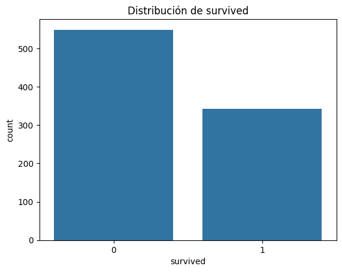

```
=== Distribución de PCLASS ===
```

| pclass | Frecuencia | Porcentaje (%) |
| --- | --- | --- |
| 3 | 491 | 55.11 |
| 1 | 216 | 24.24 |
| 2 | 184 | 20.65 |

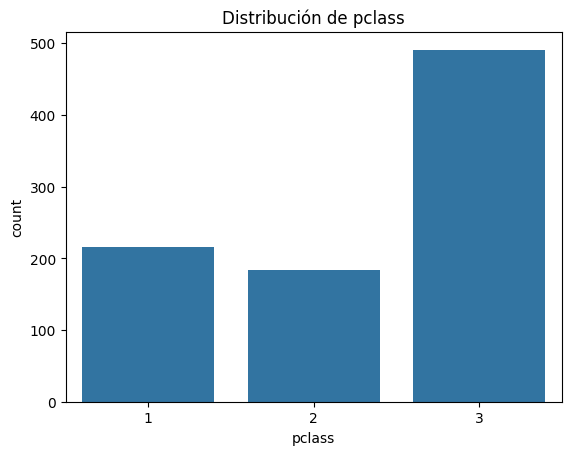

```
=== Distribución de SEX ===
```

| sex | Frecuencia | Porcentaje (%) |
| --- | --- | --- |
| male | 577 | 64.76 |
| female | 314 | 35.24 |

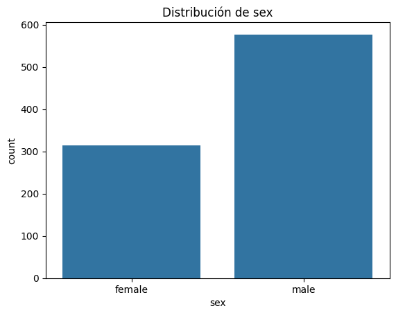

```
=== Distribución de EMBARKED ===
```

| embarked | Frecuencia | Porcentaje (%) |
| --- | --- | --- |
| S | 646 | 72.50 |
| C | 168 | 18.86 |
| Q | 77 | 8.64 |

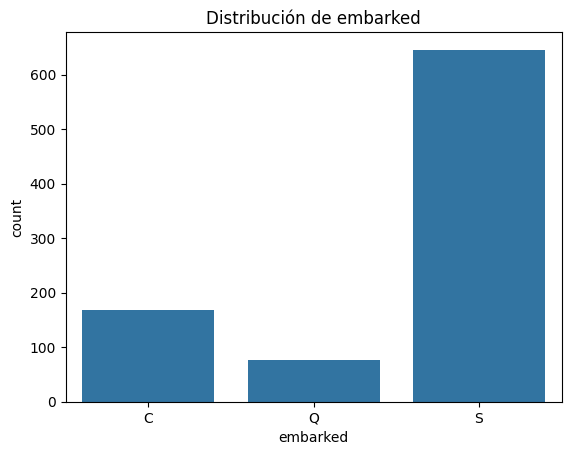

```
=== Distribución de HAS_CABIN ===
```

| Has_Cabin | Frecuencia | Porcentaje (%) |
| --- | --- | --- |
| 0 | 687 | 77.1 |
| 1 | 204 | 22.9 |

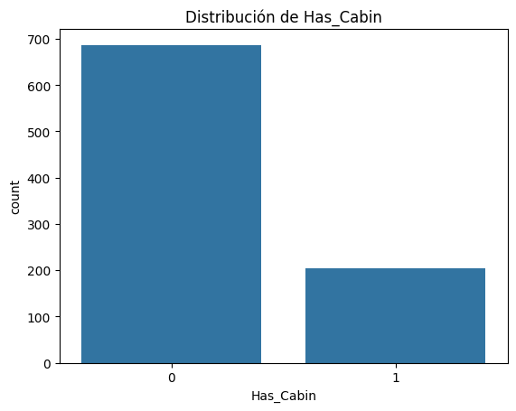

```python
# Ya tenemos nuestra lista de variables numericas y categoricas

for col in categorical_cols:
    print(f"\n=== Distribución de {col.upper()} ===")
    conteo = df_clean[col].value_counts()
    porcentaje = df_clean[col].value_counts(normalize=True) * 100

    tabla = pd.concat([conteo, porcentaje.round(2)], axis=1)
    tabla.columns = ["Frecuencia", "Porcentaje (%)"]
    display(tabla)

    sns.countplot(x = col , data = df_clean)
    plt.title(f'Distribución de {col}')
    plt.show()
```

##### Interpretacion de las graficas

Supervivencia:

- Vemos que hay mas pasajeros que no sobrevivieron (0) que los que si (1).
- La proporcion es aproximadamente 62% no sobrevivieron y 38% si sobrevivieron.

Clases sociales:

- Vemos que la mayoria de los pasajeros estaban en la tercera clase (3), seguido de la primera clase (1) y luego la segunda clase (2).
- La proporcion es aproximadamente 55% en tercera clase, 24% en primera clase y 21% en segunda clase.
- Genero:
- Vemos que hay mas pasajeros masculinos (male) que femeninos (female).
- La proporcion es aproximadamente 65% masculinos y 35% femeninos.
- Puerto de embarque:
- Vemos que la mayoria de los pasajeros embarcaron en Southampton (S), seguido de Cherbourg (C) y luego Queenstown (Q).
- La proporcion es aproximadamente 72% en Southampton, 19% en Cherbourg y 9% en Queenstown.
- Cabina asignada:
- Vemos que hay mas pasajeros sin cabina asignada (No) que con cabina asignada (Yes).
- La proporcion es aproximadamente 77% sin cabina y 23% con cabina.

## Fase 4 : Analisis del target

En esta fase vamos a analizar la variable objetivo (si el pasajero sobrevivió o no). El objetivo es entender mejor los patrones y relaciones entre las variables y la variable objetivo.

```
Tasa de supervivencia: 38.38%
```

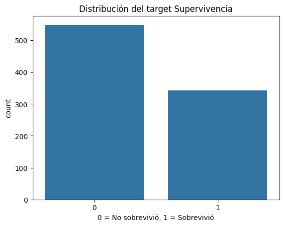

```python
tasa_supervivencia = df_clean['survived'].cat.codes.mean() * 100
print(f'Tasa de supervivencia: {tasa_supervivencia:.2f}%')

sns.countplot(x='survived', data=df_clean)
plt.title('Distribución del target Supervivencia')
plt.xlabel("0 = No sobrevivió, 1 = Sobrevivió")
plt.show()
```

Basicamente vamos a ver la tasa de supervivencia y la distribucion del target.

Vemos que la tasa de supervivencia es del 38.38%. Esto significa que aproximadamente el 38% de los pasajeros sobrevivieron al desastre del Titanic, mientras que el 62% no sobrevivieron.

Aproximadamente 2 fallecieron por cada 1 que sobrevivió.

## Fase 5: Análisis bivariado

En esta seccion vamos a explorar las relaciones entre las variables y la variable objetivo. La pregunta que respondemos es : “¿Qué me dice esta columna en relación con el target (supervivencia)?”

|  | pclass | Tasa_Supervivencia |
| --- | --- | --- |
| 0 | 1 | 0.629630 |
| 1 | 2 | 0.472826 |
| 2 | 3 | 0.242363 |

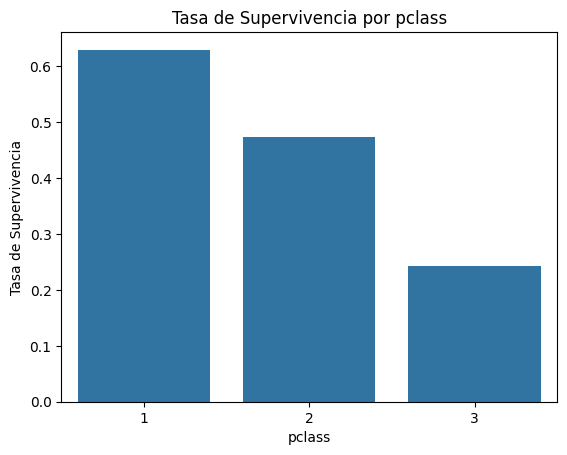

|  | sex | Tasa_Supervivencia |
| --- | --- | --- |
| 0 | female | 0.742038 |
| 1 | male | 0.188908 |

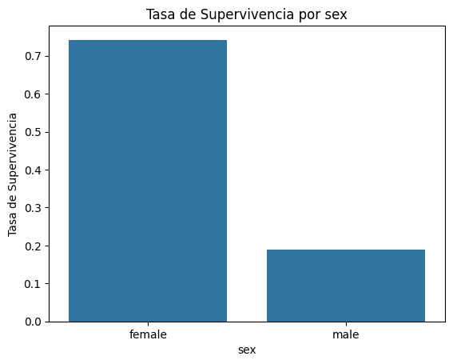

|  | embarked | Tasa_Supervivencia |
| --- | --- | --- |
| 0 | C | 0.553571 |
| 1 | Q | 0.389610 |
| 2 | S | 0.339009 |

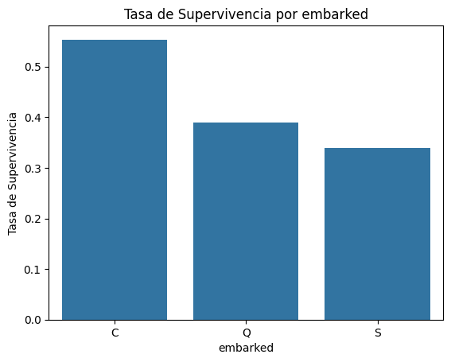

|  | Has_Cabin | Tasa_Supervivencia |
| --- | --- | --- |
| 1 | 1 | 0.666667 |
| 0 | 0 | 0.299854 |

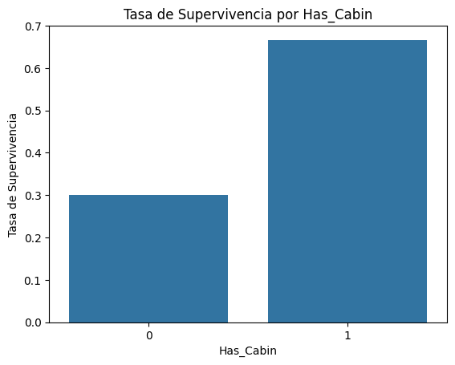

```python
def tasa_supervivencia(col):
    tabla = (
        df_clean.groupby(col)["survived"]
        .apply(lambda x: x.cat.codes.mean())
        .rename("Tasa_Supervivencia")
        .reset_index()
        .sort_values("Tasa_Supervivencia", ascending=False)
    )
    display(tabla)
    sns.barplot(x=col, y="Tasa_Supervivencia", data=tabla)
    plt.title(f"Tasa de Supervivencia por {col}")
    plt.ylabel("Tasa de Supervivencia")
    plt.show()

for c in categorical_cols:

    if c != 'survived':

        tasa_supervivencia(c)
```

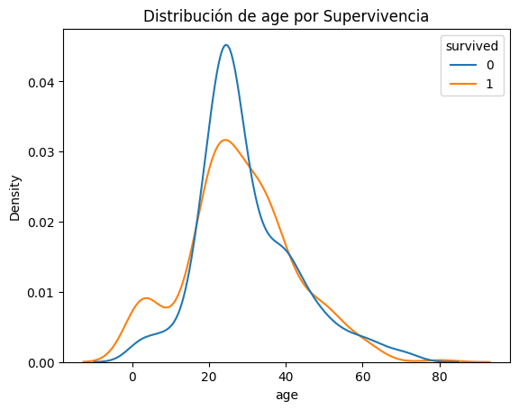

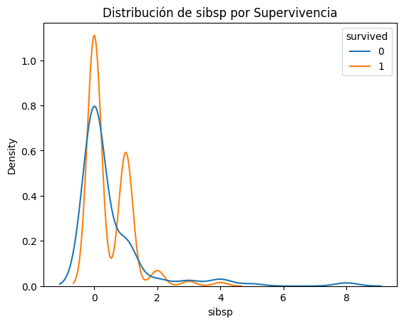

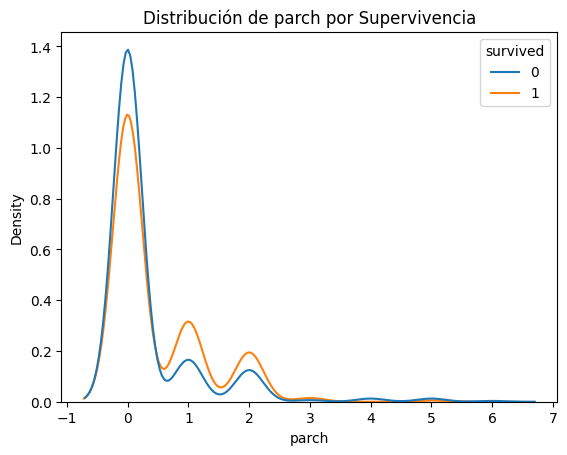

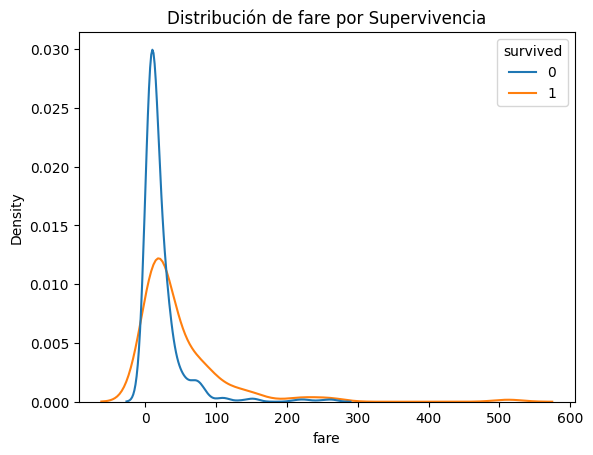

```python
for col in numeric_cols:
    sns.kdeplot(data=df_clean, x=col, hue='survived', common_norm=False)
    plt.title(f'Distribución de {col} por Supervivencia')
    plt.show()
```

### Interpretacion

Analizando la relacion entre las variables y la supervivencia, podemos observar varios patrones interesantes:

#### Interpretacion de categoricas

##### Clase social

- Los pasajeros de primera clase (Pclass = 1) tuvieron una tasa de supervivencia significativamente mayor en comparación con los de segunda y tercera clase. Esto sugiere que la clase social tuvo un impacto importante en las posibilidades de supervivencia.
- Una tasa de supervivencia del 62% para los pasajeros de primera clase, en comparación con el 47% para los de segunda clase y solo el 24% para los de tercera clase.

##### Genero

- Las mujeres tuvieron una tasa de supervivencia mucho mayor que los hombres. Esto refleja la política de "mujeres y niños primero" que se implementó durante el rescate.
- Una tasa de supervivencia del 74% para las mujeres, en comparación con solo el 19% para los hombres.
- Las mujeres sobrevieron casi 4 veces mas que los hombres.

##### Puerto de embarque

- Los pasajeros que embarcaron en Cherbourg (C) tuvieron una tasa de supervivencia más alta en comparación con los que embarcaron en Southampton (S) y Queenstown (Q). Esto podría estar relacionado con la clase social, ya que muchos pasajeros de primera clase embarcaron en Cherbourg.

El contexto es importante , este lugar llamado Cherbourg era un puerto de lujo donde embarcaban muchos pasajeros de primera clase.

- Una tasa de supervivencia del 55% para los pasajeros que embarcaron en Cherbourg, en comparación con el 34% para los de Southampton y el 38% para los de Queenstown.

Los que embarcaron en Southampton tuvieron la tasa de supervivencia mas baja. Este puerto era mas popular entre los pasajeros de tercera clase. Se puede ver la relacion entre clase social y puerto de embarque.

#### Interpretacion de numericas

##### SibSp y Parch

- Los pasajeros que viajaban con pocos familiares (SibSp y Parch bajos) tuvieron una tasa de supervivencia más alta en comparación con los que viajaban con muchos familiares. Esto podría estar relacionado con la facilidad para moverse y escapar del barco.

-Pero una diferencia es que hay mas supervivencia en Parch que en SibSp. Osea que los que viajaban con padres o hijos tenian mas posibilidades de sobrevivir que los que viajaban con hermanos o esposas.

##### Fare

- Los pasajeros que pagaron tarifas más altas (Fare alto) tuvieron una tasa de supervivencia más alta en comparación con los que pagaron tarifas más bajas. Esto podría estar relacionado con la clase social, ya que muchos pasajeros de primera clase pagaron tarifas más altas.
- Los pasajeros que pagaron tarifas muy bajas (incluyendo 0) tuvieron una tasa de supervivencia muy baja, lo que sugiere que estos pasajeros eran principalmente de tercera clase y tenían menos posibilidades de sobrevivir.

En esta fase hemos explorado las relaciones entre las variables y la variable objetivo (supervivencia). Hemos identificado varios patrones interesantes, como la influencia de la clase social, el género, el puerto de embarque y la cabina asignada en las posibilidades de supervivencia de los pasajeros del Titanic. Estos hallazgos proporcionan una comprensión más profunda de los factores que afectaron la supervivencia durante el desastre del Titanic y pueden ser útiles para futuros análisis y modelos predictivos.

La supervivencia estuvo fuertemente influenciada por la clase social, el género, el puerto de embarque y la cabina asignada. Las mujeres y los pasajeros de primera clase tuvieron las mayores tasas de supervivencia, mientras que los hombres y los pasajeros de tercera clase tuvieron las tasas más bajas.

## Fase 6 : Deteccion de outliers Cuantitativa

En esta fase vamos a identificar y manejar valores atípicos en las variables numéricas. Anteriormente ya habiamos identificado los outliers en las variables numericas utilizando boxplots. Ahora vamos a manejarlos adecuadamente.

```python
def detectar_outliers_iqr(col):
    q1 , q3 = df_clean[col].quantile([0.25, 0.75])
    iqr = q3 - q1
    limite_inf = q1 - 1.5 * iqr
    limite_sup = q3 + 1.5 * iqr
    outliers = ((df_clean[col] < limite_inf) | (df_clean[col] > limite_sup)).sum()
    print(f"{col}: {outliers} outliers detectados (límites [{limite_inf:.2f}, {limite_sup:.2f}])")
    df_clean[f"is_out_{col}"] = ((df_clean[col] < limite_inf) | (df_clean[col] > limite_sup)).astype(int)

for c in ["age", "fare"]:
    detectar_outliers_iqr(c)
```

```
age: 33 outliers detectados (límites [-0.25, 57.75])
fare: 116 outliers detectados (límites [-26.72, 65.63])
```

### Metodo IQR (Interquartile Range)

El metodo IQR es un metodo estadistico que se utiliza para identificar outliers en un conjunto de datos. El IQR se calcula como la diferencia entre el tercer cuartil (Q3) y el primer cuartil (Q1). Los outliers se definen como los valores que se encuentran por debajo de Q1 - 1.5 * IQR o por encima de Q3 + 1.5 * IQR.

## Fase 7 : Visualizacion de Sintesis (Heatmap de correlacion)

Para obtener una vision global de las relaciones entre las variables numericas, vamos a crear un mapa de calor (heatmap) de correlacion. Esto nos ayudara a identificar patrones y relaciones entre las variables de manera visual.

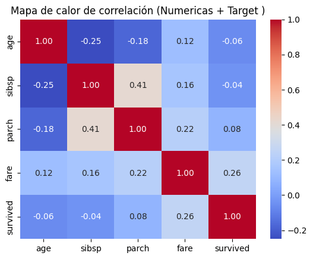

```python
corr = df_clean.assign(
    survived=df_clean['survived'].cat.codes)[['age', 'sibsp', 'parch', 'fare', 'survived']].corr()
sns.heatmap(corr, annot=True, cmap='coolwarm', fmt=".2f")
plt.title('Mapa de calor de correlación (Numericas + Target )')
plt.show()
```

### La importancia del heatmap

Un mapa de correlacion no solo valida hipotesis previas, sino que tambien revela nuevas perspectivas sobre los factores que influyeron en la supervivencia de los pasajeros del Titanic. Al identificar las variables con mayor impacto, podemos enfocar futuros análisis y modelos predictivos en estos aspectos clave, mejorando nuestra comprensión del desastre y sus implicaciones sociales.

## Fase 8: Conclusiones Finales y Reflexiones

### Objetivo

El objetivo principal de este EDA fue comprender **qué factores influyeron en la supervivencia de los pasajeros del Titanic**.  
Durante el análisis, exploramos variables demográficas, sociales y económicas, aplicando un enfoque profundo y estructurado para descubrir patrones relevantes.

### Principales hallazgos

[output not shown]

### Conclusiones generales

- La **supervivencia** en el Titanic estuvo fuertemente condicionada por el **género y la clase social**.
- Variables como **edad**, **tarifa** y **presencia de familiares** también influyeron, pero en menor medida.
- Se detectaron *outliers* coherentes con la realidad histórica (ancianos y pasajeros de primera clase), por lo que **se conservaron**.
- Los datos son ideales para **modelos predictivos de clasificación**, como regresión logística o árboles de decisión.

### Valor analítico

Este EDA demuestra:

- Capacidad para realizar un **análisis completo, estructurado y justificado**.
- Uso correcto de visualizaciones con interpretación.
- **Criterio analítico profesional** para la toma de decisiones (imputación, limpieza, tratamiento de outliers).
- Comunicación clara, visual y técnica.

### Próximos pasos

1. Implementar modelos de Machine Learning para predecir supervivencia.
2. Crear nuevas variables (por ejemplo, título del pasajero o tamaño familiar).
3. Desarrollar visualizaciones interactivas con Plotly o Dash.
4. Publicar resultados finales en un dashboard o Kaggle Notebook.

### Reflexión final

El análisis del Titanic va más allá de los números:

> **“Los datos muestran quién sobrevivió, pero el análisis explica por qué.”**

Este proyecto refleja cómo un EDA profundo puede revelar patrones humanos y sociales a partir de datos históricos.

```python
# Exportar dataset limpio (para ML)
df_clean.to_csv("../Data/train_clean.csv", index=False)
print("✅ Dataset limpio exportado correctamente como train_clean.csv")
```

```
✅ Dataset limpio exportado correctamente como train_clean.csv
```